# Cyclistic User Behavior Exploratory Data Analysis

JohnPaul Medina

2025-03-31

# Cyclistic Rider Behavior: An Exploratory Data Analysis

## Exploratory Data Analysis (EDA) Log Introduction

### Objective:

This **Exploratory Data Analysis (EDA)** investigates **behavioral differences** between casual and annual member riders. The insights will inform marketing strategies to encourage casual riders to subscribe.

### EDA Focus Areas

The analysis is structured around the following key focus points:

1. **User Distribution Analysis**
- Compare the **proportion of casual vs. member riders.**
- Identify the **scale of potential member conversions**
2. **Ride duration Patterns**
- Compare **summary statistics of ride duration** across user types.
- Determine whether **casual riders tend to take longer trips** and how this insight can be leveraged for marketing
3. **Time-Based Trends in Service Usage**
- **Hourly and weekly heatmaps** to analyze user riding pattern at different times of the day and days of the week.
- **Hourly and weekly eBike usage heatmap** to analyze eBike preference and use.
- **Seasonal trends** by analyzing monthly ride distributions to evaluate peak demand periods.
4. **Bike Type Preference & Usage Patterns**
- Identify **bike type preference** between causal and member riders.
- Explore **ride duration patterns across different bike types.**

Each of these areas will provide insights to support **marketing strategies**, optimize **pricing model**, and improve **customer engagement initiatives.**

## Preliminary General Data Exploration Distribution Analysis

First, we will analyze the **rider type distribution** to understand the dataset’s composition and the proportion of casual versus member riders.

```r
if (!exists("cleaned_data")) {
  cleaned_data <- readRDS(cleaned_data_rds)
}

# Compute Rider Counts
member_count <- sum(cleaned_data$member_casual == "member")
casual_count <- sum(cleaned_data$member_casual == "casual")
total_accounts <- member_count + casual_count

# Create a summary table
rider_type_summary <- data.frame(
  Rider_Type = c("Casual Riders", "Member Riders", "Total Riders"),
  Count = c(casual_count, member_count, total_accounts),
  Percentage = c(
    (casual_count / total_accounts) * 100,
    (member_count / total_accounts) * 100,
    100
  )
)

# Print the result as a formatted table
knitr::kable(rider_type_summary,
             caption = "Rider Type Distribution",
             digits = 2,
             format = "pipe")
```

Rider Type Distribution

| Rider_Type | Count | Percentage |
| --- | --- | --- |
| Casual Riders | 2144349 | 36.16 |
| Member Riders | 3785713 | 63.84 |
| Total Riders | 5930062 | 100.00 |

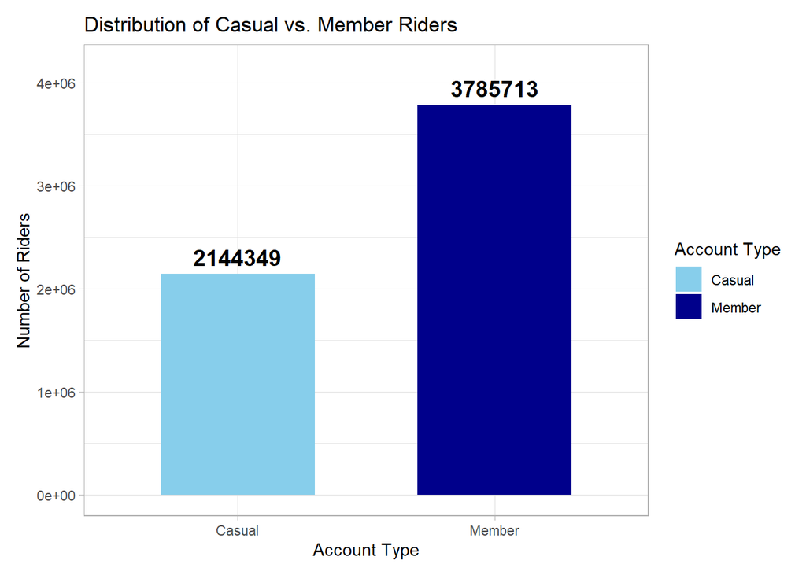

```r
# Create a Data Frame for Plotting
account_counts <- data.frame(
  account_type = c("Casual", "Member"),
  count = c(casual_count, member_count)
)

# Plot Bar Chart of rider type distribution
p <- ggplot(account_counts, aes(x = account_type,
                                y = count, fill = account_type)) +
  geom_bar(stat = "identity", width = 0.6) +  # Adjust width for aesthetics
  geom_text(aes(label = count), vjust = -0.5, size = 5, fontface = "bold") +
  labs(
    title = "Distribution of Casual vs. Member Riders",
    x = "Account Type",
    y = "Number of Riders",
    fill = "Account Type"
  ) +
  scale_fill_manual(values = c("Casual" = "skyblue", "Member" = "darkblue")) +
  theme_light() +
  expand_limits(y = max(account_counts$count) * 1.1) +
  theme(plot.margin = margin(10, 10, 10, 10))

# Display the Plot
print(p)
```

### Analysis and Key Insights

- To ensure **fair comparisons**, percentages or averages should be used **instead of raw counts** to avoid skewed results due to the **imbalance between casual and member totals.**
- This **high number of casual riders** presents an opportunity for **membership conversion marketing.**
- To ensure fair comparisons, **percentages or averages** should be used instead of raw counts to avoid skewed results due to the **imbalance between casual and member totals.**

## Member versus Casual Rider Ride Duration Summary Comparison

This section will compare the summary of ride duration for member and casual riders, focusing on which rider type has longer ride duration and by how much.

```r
# Study the summary of ride_duration of casual riders vs annual member riders
casual_summary <-
  summary(cleaned_data$ride_duration[cleaned_data$member_casual=="casual"])
member_summary <-
  summary(cleaned_data$ride_duration[cleaned_data$member_casual == "member"])


# Create a data frame with the summary statistics
summary_data <- data.frame(
  Statistic = rep(names(casual_summary),2),
  Value = c(as.numeric(casual_summary), as.numeric(member_summary)),
  Rider_Type = rep(c("Casual", "Member"), each = length(casual_summary))
)

# Convert the data frame to wide format for table display
ride_duration_summary <- tidyr::pivot_wider(
  summary_data,
  names_from = Rider_Type,
  values_from = Value
)

# Compute Percentage Difference only for Q1, Median, Mean, and Q3
ride_duration_summary$Percent_Difference <- ifelse(
  ride_duration_summary$Statistic %in% c("1st Qu.", "Median", "Mean", "3rd Qu."),
  round(((ride_duration_summary$Casual - ride_duration_summary$Member) /
         ride_duration_summary$Member) * 100, 2),
  NA  # Leave Min and Max without percentage difference
)

# Display summary table
knitr::kable(ride_duration_summary,
             caption = "Ride Duration Summary by Rider Type",
             digits = 2,
             format = "pipe")
```

Ride Duration Summary by Rider Type

| Statistic | Casual | Member | Percent_Difference |
| --- | --- | --- | --- |
| Min. | 0.00 | 0.00 | NA |
| 1st Qu. | 6.78 | 5.14 | 31.95 |
| Median | 12.09 | 8.70 | 38.98 |
| Mean | 21.06 | 12.23 | 72.12 |
| 3rd Qu. | 22.69 | 14.75 | 53.78 |
| Max. | 1439.83 | 1437.77 | NA |

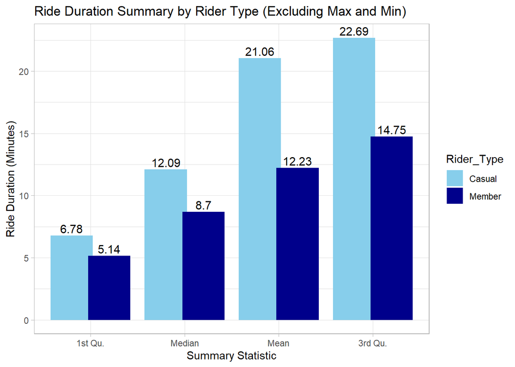

```r
# Exclude "Max" and "Min" statistics from the data
summary_data <- summary_data %>%
  filter(Statistic %in% c("1st Qu.", "Median", "Mean", "3rd Qu."))

# Ensure correct ordering of statistics
summary_data$Statistic <- factor(summary_data$Statistic,
                                 levels = c("1st Qu.", "Median", "Mean", "3rd Qu."))

# Create the dodge bar graph with labels
ggplot(summary_data, aes(x = Statistic, y = Value, fill = Rider_Type)) +
  geom_bar(stat = "identity", position = position_dodge(width = 0.8)) +
  geom_text(aes(label = round(Value, 2)),
            position = position_dodge(width = 0.8),
            vjust = -0.3, size = 4) + # Adjust vjust for padding
  scale_fill_manual(values = c("Casual" = "skyblue", "Member" = "darkblue")) +
  labs(title = "Ride Duration Summary by Rider Type (Excluding Max and Min)",
       x = "Summary Statistic",
       y = "Ride Duration (Minutes)") +
  theme_light()
```

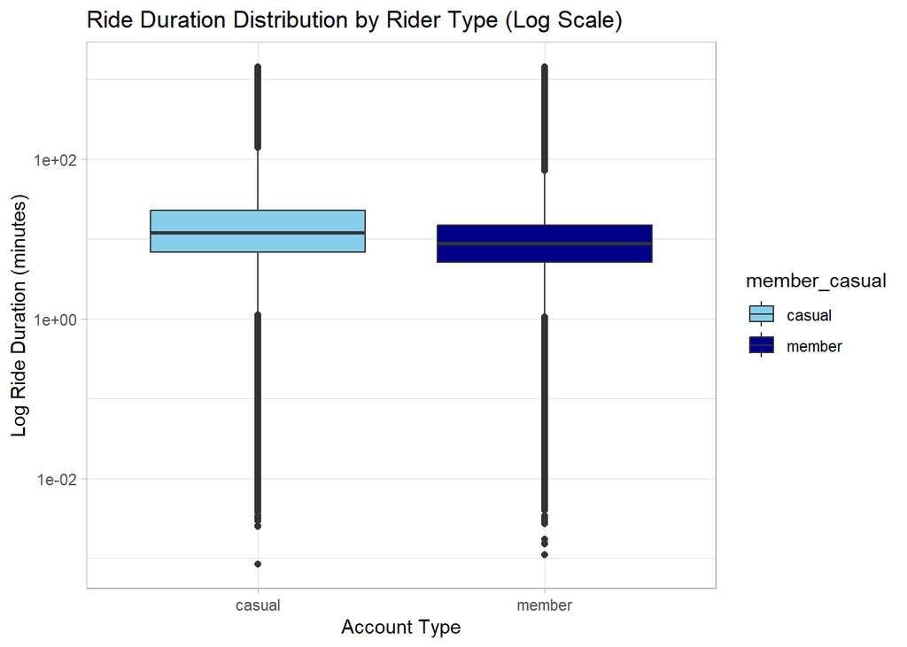

```r
# Box plot of the summaries of casual vs member ride durations
ggplot(cleaned_data, aes(x = member_casual, y = ride_duration, fill = member_casual)) +
  geom_boxplot() +
  scale_y_log10() +  # Apply log scale to y-axis
  labs(
    title = "Ride Duration Distribution by Rider Type (Log Scale)",
    x = "Account Type",
    y = "Log Ride Duration (minutes)"
  ) +
  scale_fill_manual(values = c("casual" = "skyblue", "member" = "darkblue")) +
  theme_light()
```

### Analysis and Key Inisghts

- Based on numerical and visual comparison of the summaries of casual and member ride duration, casual riders tend to use the service longer than members.
- The box plot shows that casual riders tend to take longer rides than members at every quartile measurement.
- Member ride duration from Q1 to Q3 are contained within a **narrower range**, indicating a more **consistent** riding pattern.

## Ride Type Preference for Casual and Member Riders

This section analyzes the ride type preferences of casual and members. We are using percentages with respect to rider type in order to gain insight on how often each rider type use a classic bike, eBike, and eScooter.

```r
# Compute the percentage of use of ride type based on rider type.
ride_type_percentage <- cleaned_data %>%
  group_by(member_casual, rideable_type) %>%
  summarise(count = n(), .groups="drop") %>%
  group_by(member_casual) %>%
  mutate(percent = (count / sum(count)) * 100) %>%
  ungroup()

# Create a formatted table for better readability
knitr::kable(
  ride_type_percentage,
  caption = "Bike Type Usage by Rider Type (Percentage Breakdown)",
  digits = 2,
  format = "pipe"
)
```

Bike Type Usage by Rider Type (Percentage Breakdown)

| member_casual | rideable_type | count | percent |
| --- | --- | --- | --- |
| casual | classic_bike | 971609 | 45.31 |
| casual | electric_bike | 1089307 | 50.80 |
| casual | electric_scooter | 83433 | 3.89 |
| member | classic_bike | 1793696 | 47.38 |
| member | electric_bike | 1934435 | 51.10 |
| member | electric_scooter | 57582 | 1.52 |

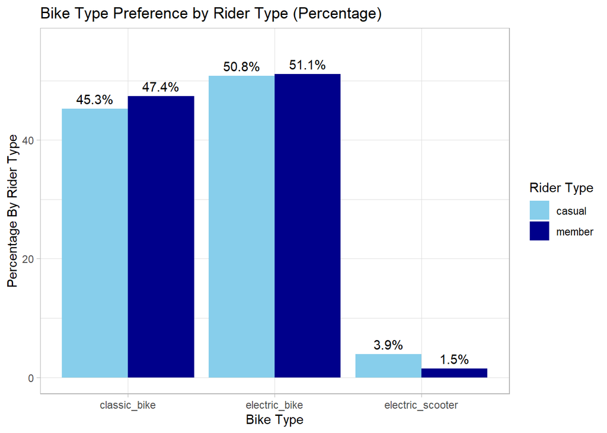

```r
# Visualize the rideable_type vs member_casual as a bar graph
ggplot(ride_type_percentage, aes(x = rideable_type, y = percent, fill = member_casual)) +
  geom_col(position = "dodge") +
  labs(
    title = "Bike Type Preference by Rider Type (Percentage)",
    x = "Bike Type",
    y = "Percentage By Rider Type",
    fill = "Rider Type"
  ) +
  scale_fill_manual(values=c("casual"="skyblue", member="darkblue")) +
  theme_light() +
  ylim(0, max(ride_type_percentage$percent) + 5) +
  geom_text(aes(label=sprintf("%.1f%%", percent)),
            position = position_dodge(width = 0.9), vjust = -0.5)
```

### Analysis and Key Insights

- Both casual and members show a slightly higher preference in e-bikes compared classic bikes which are both nearly half the rides each.
- Rental for **e-scooters** is 3.89% for casual riders and 1.52% for members.

## Ride Duration Analysis by Ride Type and Rider Type

This section analyzes the average ride duration for each rider type with respect to ride type. This will give us an insight on how long each rider type tend to use classic bikes, eBikes, and eScooters.

```r
# Compute average ride duration per bike type **and** rider type
avg_ride_duration_by_type <- cleaned_data %>%
  group_by(member_casual, rideable_type) %>%
  summarise(
    avg_duration = mean(ride_duration, na.rm = TRUE),
    median_duration = median(ride_duration, na.rm = TRUE),
    count = n(),
    .groups = "drop"
  ) %>%
  group_by(member_casual) %>%
  mutate(percent_of_rider_type = (count / sum(count)) * 100) %>%
  ungroup() %>%
  arrange(rideable_type, desc(avg_duration))  # Sort for better visualization

# Table: Average Ride Duration per Bike Type and Rider Type (With Percentages)
knitr::kable(
  avg_ride_duration_by_type %>% select(-count),  # Remove count column since we now use percentage
  caption = "Average Ride Duration by Bike Type and Rider Type (Percentage of Rider Type)",
  digits = 2,
  format = "pipe"
)
```

Average Ride Duration by Bike Type and Rider Type (Percentage of Rider Type)

| member_casual | rideable_type | avg_duration | median_duration | percent_of_rider_type |
| --- | --- | --- | --- | --- |
| casual | classic_bike | 28.95 | 16.04 | 45.31 |
| member | classic_bike | 13.36 | 9.19 | 47.38 |
| casual | electric_bike | 14.70 | 9.87 | 50.80 |
| member | electric_bike | 11.30 | 8.37 | 51.10 |
| casual | electric_scooter | 12.19 | 8.42 | 3.89 |
| member | electric_scooter | 8.45 | 6.71 | 1.52 |

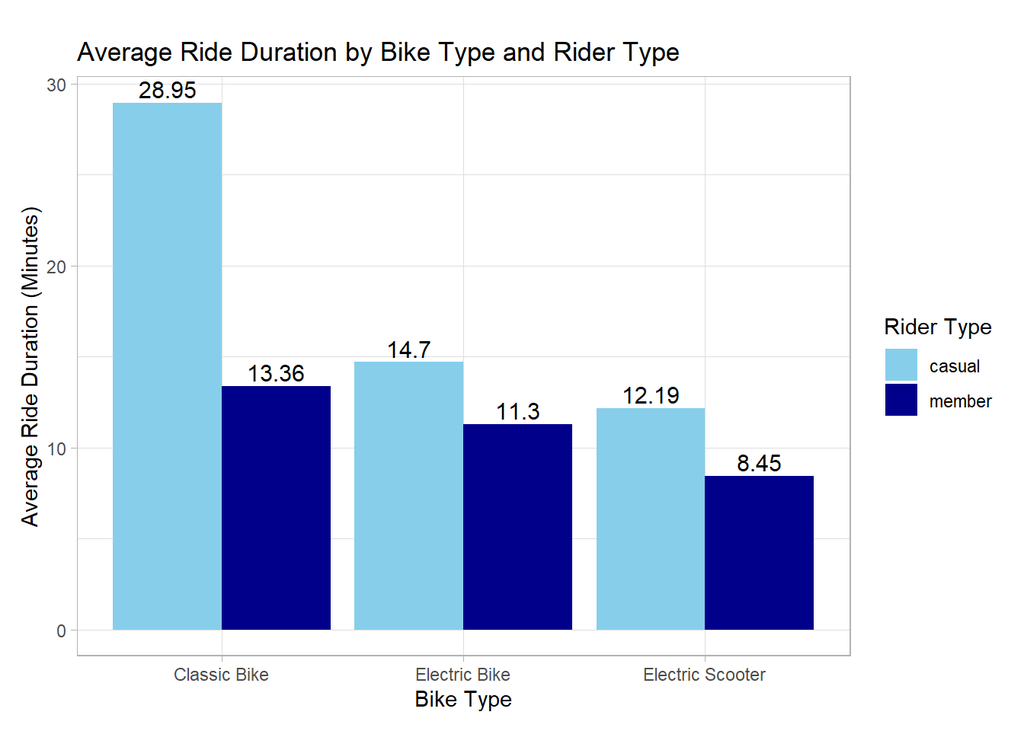

```r
# Dodge Bar Chart: Ride Duration per Bike Type and Rider Type
ggplot(avg_ride_duration_by_type, aes(x = rideable_type, y = avg_duration, fill = member_casual)) +
  geom_col(position = "dodge") +
  geom_text(aes(label = round(avg_duration, 2)),
            position = position_dodge(width = 0.9),
            vjust = -0.3, size = 4) +  # Add value labels with padding
  labs(
    title = "Average Ride Duration by Bike Type and Rider Type",
    x = "Bike Type",
    y = "Average Ride Duration (Minutes)",
    fill = "Rider Type"
  ) +
  scale_fill_manual(values = c("casual" = "skyblue", "member" = "darkblue")) +
  scale_x_discrete(labels = c("classic_bike" = "Classic Bike",
                              "electric_bike" = "Electric Bike",
                              "electric_scooter" = "Electric Scooter")) +
  theme_light() +
  theme(plot.margin = margin(20, 10, 10, 10))  # Add padding to prevent cutoff
```

## Binning `ride_duration`

Analyzing continuous data such as `ride_duration` is important but it can be a cause of noise in some analysis. **Binning continuous data** does not only organize data but it also significantly **reduces noise.**

### Identifying Bin Thresholds

- Based on previous analysis of casual and member `ride_duration` summaries, the **1st quartile** values for casual (6.78 minutes) and members (5.14 minutes) indicates that 5 - 7 minutes is a plausible threshold for **short rides**.
- Upon examination of data distribution based on selected thresholds (see table below), the number of rides up to the 30 minute mark contains 90.19% of the total ride; this is a plausible threshold for **medium rides**.
- Using the same table, rides up to the 60-minute mark consists of 97.52% of the data. The 60-minute mark is also a point where the increase in data distribution slows down and thus is chosen as the upper bound for **long rides.**
- Any ride **beyond 60 minutes** is considered **extended.**

```r
# Define duration thresholds for binning consideration
duration_thresholds <- c(5, 10, 15, 20, 30, 40, 50, 60, 70, 80, 90, 100, 110, 120, 130)

# Compute total number of rides
total_rides <- nrow(cleaned_data)

# Compute the number of rides that are <= each threshold
ride_duration_summary <- data.frame(
  "Duration_Threshold (min)" = duration_thresholds,
  "Number_of_Rides" = sapply(duration_thresholds, function(x) {
    sum(cleaned_data$ride_duration <= x)
  })
)

# Compute the percentage of total rides for each range
ride_duration_summary$Percentage_of_Total <- round(
  (ride_duration_summary$Number_of_Rides / total_rides) * 100, 2
)

# Display the table
knitr::kable(
  ride_duration_summary,
  caption = "Ride Duration Summary (Cumulative Intervals) with Percentage",
  digits = 2,
  format = "pipe"
)
```

Ride Duration Summary (Cumulative Intervals) with Percentage

| Duration_Threshold..min. | Number_of_Rides | Percentage_of_Total |
| --- | --- | --- |
| 5 | 1229757 | 20.74 |
| 10 | 3047719 | 51.39 |
| 15 | 4138906 | 69.80 |
| 20 | 4752797 | 80.15 |
| 30 | 5348269 | 90.19 |
| 40 | 5599912 | 94.43 |
| 50 | 5721109 | 96.48 |
| 60 | 5783027 | 97.52 |
| 70 | 5821096 | 98.16 |
| 80 | 5846632 | 98.59 |
| 90 | 5864322 | 98.89 |
| 100 | 5877461 | 99.11 |
| 110 | 5887220 | 99.28 |
| 120 | 5894699 | 99.40 |
| 130 | 5900317 | 99.50 |

An Empirical Cumulative Distribution Function (ECDF) plot supports the logic behind the identified thresholds.

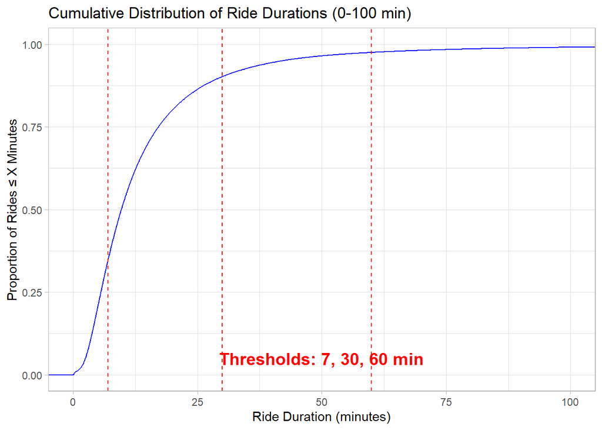

```r
ggplot(cleaned_data, aes(x = ride_duration)) +
  stat_ecdf(geom = "step", color = "blue") +
  coord_cartesian(xlim = c(0, 100)) +  # Adjust x-axis to focus on shorter rides
  geom_vline(xintercept = c(7, 30, 60), linetype = "dashed", color = "red") +
  annotate("text", x = 50, y = 0.05, label = "Thresholds: 7, 30, 60 min",
         color = "red", size = 5, fontface = "bold", hjust = 0.5) +
  labs(
    title = "Cumulative Distribution of Ride Durations (0-100 min)",
    x = "Ride Duration (minutes)",
    y = "Proportion of Rides ≤ X Minutes"
  ) +
  theme_light()
```

Binning and conversion of `ride_category` to a factor.

```r
#Ensure that ride_duration is numeric
cleaned_data <- cleaned_data %>%
  mutate(ride_duration = as.numeric(ride_duration))

# Set binning thresholds and add the column
cleaned_data <- cleaned_data %>%
  mutate(ride_category = case_when(
         ride_duration <= 7 ~ "short",
         ride_duration <= 30 ~ "medium",
         ride_duration <= 60 ~ "long",
         TRUE ~ "extended"
  ))

# Convert ride_category into a factor for better plotting and order
cleaned_data <- cleaned_data %>%
  mutate(
    ride_category = factor(ride_category,
                           levels=c("short","medium","long","extended"))
  )

table(cleaned_data$ride_category)
```

```
##
##    short   medium     long extended
##  2043481  3304788   434758   147035
```

```r
#Update the dataset with the added ride_category
#saveRDS(cleaned_data, file = cleaned_data_rds) - commented out for demo
```

**Visualization** of `ride_category` bins based on percentage of total rides.

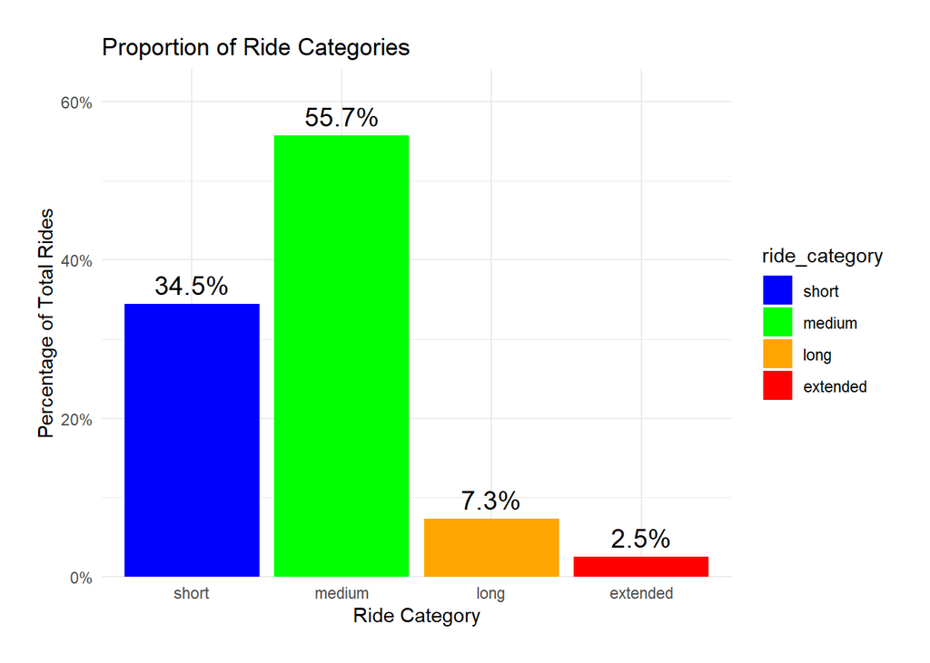

```r
ggplot(cleaned_data, aes(x = ride_category, fill = ride_category)) +
  geom_bar(aes(y = after_stat(count) / sum(after_stat(count)))) +
  geom_text(
    stat = "count",
    aes(y = after_stat(count) / sum(after_stat(count)),
        label = scales::percent(after_stat(count) / sum(after_stat(count)), accuracy = 0.1)),
    vjust = -0.5,
    size = 5
  ) +
  scale_y_continuous(labels = scales::percent, expand = expansion(mult = c(0, 0.15))) +
  labs(
    title = "Proportion of Ride Categories",
    x = "Ride Category",
    y = "Percentage of Total Rides"
  ) +
  theme_minimal() +
  scale_fill_manual(values = c("short" = "blue", "medium" = "green",
                               "long" = "orange", "extended" = "red")) +
  theme(
    plot.margin = margin(20, 20, 20, 20)  # Adds padding to prevent cutoff
  )
```

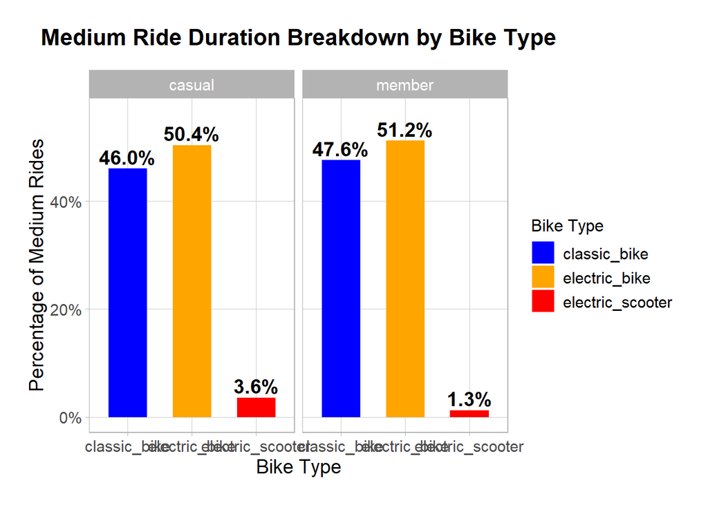

```r
# Filter data for medium rides only
medium_rides <- cleaned_data %>%
  filter(ride_category == "medium") %>%
  group_by(member_casual, rideable_type) %>%
  summarise(count = n(), .groups = "drop") %>%
  group_by(member_casual) %>%
  mutate(percent = (count / sum(count)) * 100)

# Create visualization for medium rides
plot_medium_rides <- ggplot(medium_rides, aes(x = rideable_type, y = percent, fill = rideable_type)) +
  geom_bar(stat = "identity", position = "dodge", width = 0.6) +
  geom_text(aes(label = sprintf("%.1f%%", percent)),
            position = position_dodge(width = 0.6), vjust = -0.3, size = 5, fontface = "bold") +
  scale_fill_manual(values = c("classic_bike" = "blue", "electric_bike" = "orange", "electric_scooter" = "red")) +
  labs(
    title = "Medium Ride Duration Breakdown by Bike Type",
    x = "Bike Type",
    y = "Percentage of Medium Rides",
    fill = "Bike Type"
  ) +
  facet_wrap(~member_casual) +  # Separate casual and member riders
  scale_y_continuous(labels = scales::percent_format(scale = 1)) +
  theme_light() +
  expand_limits(y = max(medium_rides$percent) * 1.1) +
  theme(
    plot.margin = margin(20, 20, 20, 20),
    text = element_text(size = 14),
    legend.title = element_text(size = 12),
    plot.title = element_text(face = "bold", size = 16, hjust = 0.5, margin = margin(b = 15)),
    panel.grid.major = element_line(color = "gray80"),
    panel.grid.minor = element_blank()
  )

print(plot_medium_rides)
```

### Analysis and Key Insights

- **90.19% of rides** are 30 minutes or shorter, thus the interval 7 - 30 minutes is an appropriate choice for “medium” duration type of ride.
- The **ECDF plot** confirms that ride duration increases at a much slower rate beyond the 60-minute mark.
- With **ride categories now set**, we can begin the analysis of **time-based** rider behaviors to discover trends in peak usage, hourly demands, daily demands, and seasonal ride fluctuations.
- **Medium rides** make up more than half the rides for casual riders and members and both casual and member riders show a slight preference for eBikes for their medium rides.

## Time-Based Analysis

This section tackles the time-based behaviors of casual and member riders. Here we will examine bike usage and bike-type usage varies between hours, days, and season.

## Ride Duration Summary based on Day of the Week

```r
# Compute ride duration summary by day of week for casual riders
casual_summary <- cleaned_data %>%
  filter(member_casual == "casual") %>%
  group_by(day_of_week) %>%
  summarise(
    Min = min(ride_duration, na.rm = TRUE),
    Q1 = quantile(ride_duration, 0.25, na.rm = TRUE),
    Median = median(ride_duration, na.rm = TRUE),
    Mean = mean(ride_duration, na.rm = TRUE),
    Q3 = quantile(ride_duration, 0.75, na.rm = TRUE),
    Max = max(ride_duration, na.rm = TRUE),
    .groups = "drop"
  ) %>%
  mutate(member_casual = "casual")

# Compute ride duration summary by day of week for member riders
member_summary <- cleaned_data %>%
  filter(member_casual == "member") %>%
  group_by(day_of_week) %>%
  summarise(
    Min = min(ride_duration, na.rm = TRUE),
    Q1 = quantile(ride_duration, 0.25, na.rm = TRUE),
    Median = median(ride_duration, na.rm = TRUE),
    Mean = mean(ride_duration, na.rm = TRUE),
    Q3 = quantile(ride_duration, 0.75, na.rm = TRUE),
    Max = max(ride_duration, na.rm = TRUE),
    .groups = "drop"
  ) %>%
  mutate(member_casual = "member")

# Combine the summaries
ride_duration_summary <- bind_rows(casual_summary, member_summary)

# Display summary as a table
pander(ride_duration_summary,
       caption = "Ride Duration Summary by Day of the Week (Casual vs. Member)")
```

Ride Duration Summary by Day of the Week (Casual vs. Member)

| day_of_week | Min | Q1 | Median | Mean | Q3 | Max | member_casual |
| --- | --- | --- | --- | --- | --- | --- | --- |
| Sunday | 0.00295 | 7.774 | 14.25 | 24.37 | 27.03 | 1439 | casual |
| Monday | 0.002533 | 6.346 | 11.3 | 20.42 | 21.66 | 1423 | casual |
| Tuesday | 0.00085 | 6.093 | 10.42 | 18.13 | 18.89 | 1438 | casual |
| Wednesday | 0.00315 | 6.243 | 10.72 | 18.6 | 19.33 | 1439 | casual |
| Thursday | 0.004383 | 6.183 | 10.62 | 18.24 | 19.2 | 1432 | casual |
| Friday | 0.002483 | 6.667 | 11.77 | 20.34 | 21.9 | 1436 | casual |
| Saturday | 0.003433 | 7.879 | 14.33 | 23.92 | 26.71 | 1440 | casual |
| Sunday | 0.0032 | 5.376 | 9.383 | 13.62 | 16.51 | 1429 | member |
| Monday | 0.002683 | 4.966 | 8.317 | 11.7 | 14.02 | 1420 | member |
| Tuesday | 0.002733 | 5.055 | 8.467 | 11.74 | 14.15 | 1437 | member |
| Wednesday | 0.001733 | 5.133 | 8.633 | 11.92 | 14.43 | 1426 | member |
| Thursday | 0.0011 | 5.072 | 8.508 | 11.7 | 14.21 | 1437 | member |
| Friday | 0.00275 | 5.051 | 8.504 | 11.95 | 14.35 | 1399 | member |
| Saturday | 0.0015 | 5.511 | 9.533 | 13.58 | 16.54 | 1438 | member |

### Analysis and Key Insights

- Ride duration for casual riders peak on the weekends.
- Ride duration for members also peaks on the weekends but not as drastic as those of casual riders.
- Ride duration summary values are consistent outside of peak days.

## Visualization of Median Ride Duration for Each Day of the Week

Based on the analysis of the value summaries for each day for both rider types, the presence of very small and very large min and max values can easily skew the value of the mean, thus we are going to use the median as average.

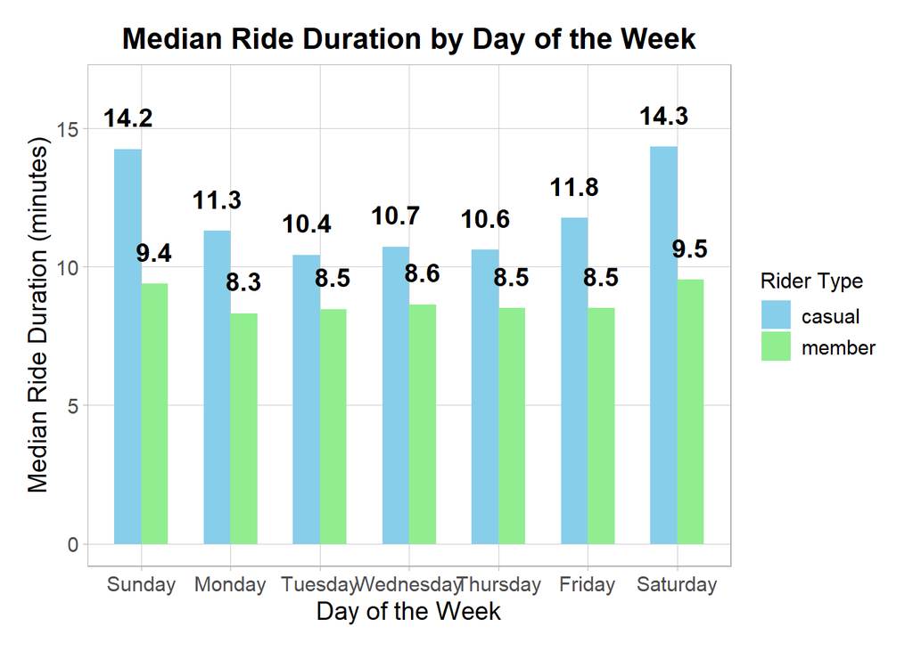

```r
# Analysis of medians each day of the week
median_ride_duration_summary <- ride_duration_summary %>%
  select(day_of_week, Median, member_casual)

# Ensure correct ordering of day_of_week
median_ride_duration_summary$day_of_week <- factor(
  median_ride_duration_summary$day_of_week,
  levels = c("Sunday", "Monday", "Tuesday", "Wednesday", "Thursday", "Friday", "Saturday")
)

# Ensure member_casual is treated as a factor
median_ride_duration_summary$member_casual <- factor(
  median_ride_duration_summary$member_casual,
  levels = c("casual", "member")
)

# Create the bar plot
plot_median_duration <- ggplot(median_ride_duration_summary,
                               aes(x = day_of_week, y = Median, fill = member_casual)) +
  geom_bar(stat = "identity", position = "dodge", width = 0.6) +  # Use dodge for side-by-side bars
  geom_text(aes(label = round(Median, 1)),
            position = position_dodge(width = 0.6), vjust = -1.2, size = 5,
            fontface = "bold") +
  scale_fill_manual(values = c("casual" = "skyblue", "member" = "lightgreen")) +
  labs(
    title = "Median Ride Duration by Day of the Week",
    x = "Day of the Week",
    y = "Median Ride Duration (minutes)",
    fill = "Rider Type"
  ) +
  expand_limits(y = max(median_ride_duration_summary$Median) * 1.15) +
  theme_light() +
  theme(
    plot.margin = margin(15,15,15,15),
    text = element_text(size = 14),
    legend.title = element_text(size = 12),
    plot.title = element_text(face = "bold", size = 16, hjust = 0.5),
    panel.grid.major = element_line(color = "gray80"),
    panel.grid.minor = element_blank()
  )

# Display the plot
print(plot_median_duration)
```

### Analysis and Key Insights

- Both casual and member rider median ride duration shows an uptick during the weekend.
- Member median value are consistently in the 8-9 minute range throughout the week.
- Casual rider median values rise significantly during the weekend and follow a parabolic pattern during the week.

## Percentage of Rides Based on Day of the Week

This section will analyze and visualize the riding behavior of casual and members based on percentage with respect to rider type and day of the week.

```r
# Compute ride percentages within each rider type
day_of_week_percent <- cleaned_data %>%
  group_by(member_casual, day_of_week) %>%
  summarise(count = n(), .groups = "drop") %>%
  group_by(member_casual) %>%
  mutate(percentage = (count / sum(count)) * 100) %>%
  ungroup()

# Print summary table
print(day_of_week_percent)
```

```
## # A tibble: 14 × 4
##    member_casual day_of_week  count percentage
##    <chr>         <ord>        <int>      <dbl>
##  1 casual        Sunday      366494       17.1
##  2 casual        Monday      252305       11.8
##  3 casual        Tuesday     231860       10.8
##  4 casual        Wednesday   270206       12.6
##  5 casual        Thursday    266004       12.4
##  6 casual        Friday      315128       14.7
##  7 casual        Saturday    442352       20.6
##  8 member        Sunday      421772       11.1
##  9 member        Monday      543479       14.4
## 10 member        Tuesday     581093       15.3
## 11 member        Wednesday   625168       16.5
## 12 member        Thursday    589114       15.6
## 13 member        Friday      538311       14.2
## 14 member        Saturday    486776       12.9
```

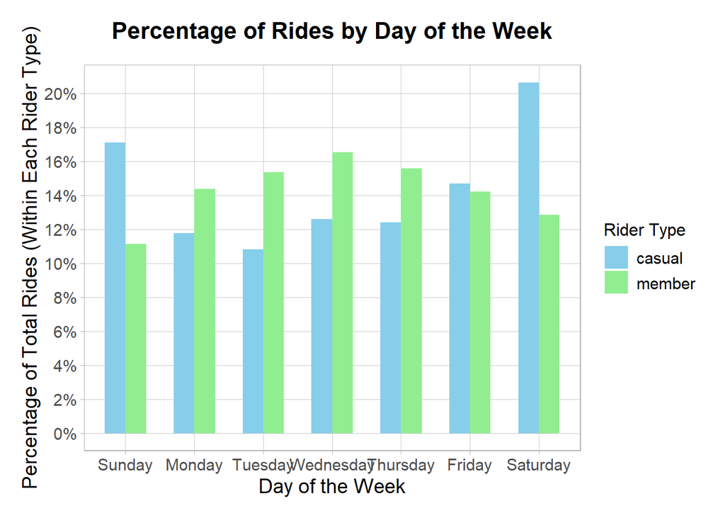

```r
# Create a grouped bar chart for ride percentage per day
plot_ride_percentage <- ggplot(day_of_week_percent,
                               aes(x = day_of_week, y = percentage, fill = member_casual)) +
  geom_bar(stat = "identity", position = "dodge", width = 0.6) +  # Dodge for side-by-side bars
  scale_fill_manual(values = c("casual" = "skyblue", "member" = "lightgreen")) +  # Custom colors
  scale_y_continuous(labels = scales::percent_format(scale = 1),
                   breaks = seq(0, max(day_of_week_percent$percentage), by = 2)) +

  labs(
    title = "Percentage of Rides by Day of the Week",
    x = "Day of the Week",
    y = "Percentage of Total Rides (Within Each Rider Type)",
    fill = "Rider Type"
  ) +
  theme_light() +
  theme(
    plot.margin = margin(15, 15, 15, 15),
    text = element_text(size = 14),
    legend.title = element_text(size = 12),
    plot.title = element_text(face = "bold", size = 16, hjust = 0.5,
                              margin = margin(b=15)),
    panel.grid.major = element_line(color = "gray80"),
    panel.grid.minor = element_blank()
  )

# Display the percentage-based plot
print(plot_ride_percentage)
```

### Analysis and Key Insights

- Casual ridership **peak on weekends**, but significant weekday usage suggests that many casual riders are **local commuters, not just tourists**.
- Members show **consistent weekday usage**, peaking midweek, but without drastic fluctuations.
- This suggests a **conversion opportunity** for local casual riders who use the service regularly during weekdays.

## Ride Count Heatmap Based on Hours of Each Day of the Week

This section will analyze rider service usage for every hour of each day of the week. The goal is to determine peak times and days of ride starts. This will compare the overall heat map and a **casual riders only** heat map.

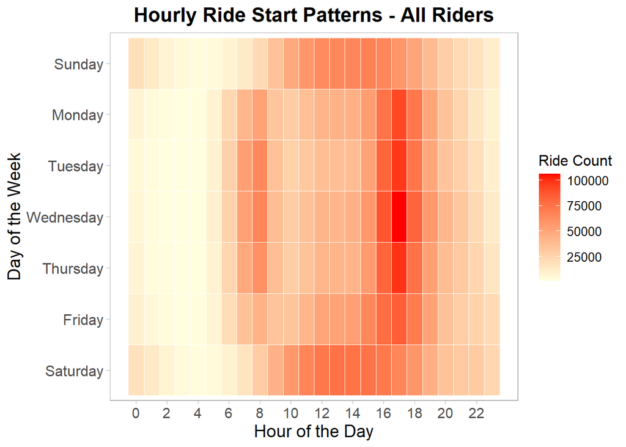

```r
# Extract hour of the day from ride start time
cleaned_data <- cleaned_data %>%
  mutate(start_hour = hour(started_at))  # Extract hour (0-23)

# Summarize total ride counts by hour and day of week
hourly_rides_summary <- cleaned_data %>%
  group_by(day_of_week, start_hour) %>%
  summarise(ride_count = n(), .groups = "drop")

# Create a heatmap using ggplot
plot_hourly_heatmap <- ggplot(hourly_rides_summary,
                              aes(x = start_hour, y = fct_rev(day_of_week), fill = ride_count)) +
  geom_tile(color = "white") +  # Adds gridlines
  scale_fill_gradient(low = "lightyellow", high = "red") +  # Heatmap color scheme
  scale_x_continuous(breaks = seq(0, 23, by = 2)) + # Show labels at intervals of 2 hours
  labs(
    title = "Hourly Ride Start Patterns - All Riders",
    x = "Hour of the Day",
    y = "Day of the Week",
    fill = "Ride Count"
  ) +
  theme_light() +
  theme(
    plot.title = element_text(face = "bold", size = 16, hjust = 0.5),
    text = element_text(size = 14),
    axis.text.y = element_text(size = 12),
    legend.title = element_text(size = 12),
    legend.text = element_text(size = 10),
    panel.grid.major = element_blank(),
    panel.grid.minor = element_blank()
  )

# Display the heatmap
print(plot_hourly_heatmap)
```

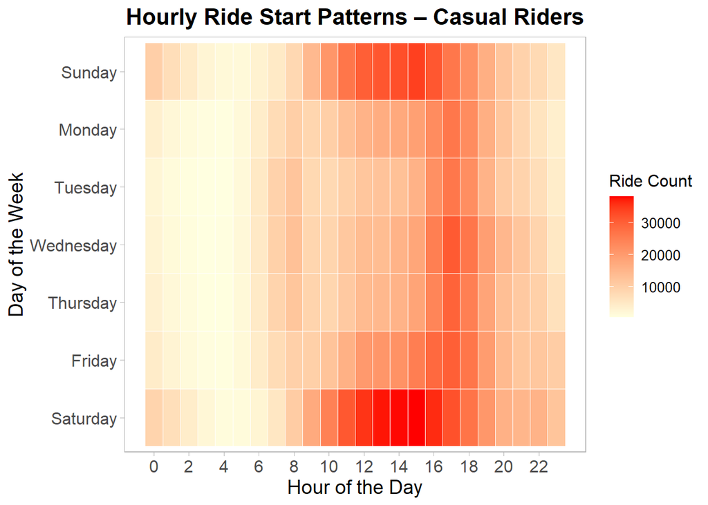

```r
# Casual riders heatmap
# Filter dataset for only casual riders
casual_rides_summary <- cleaned_data %>%
  filter(member_casual == "casual") %>%
  group_by(day_of_week, start_hour) %>%
  summarise(ride_count = n(), .groups = "drop")

# Generate the heatmap for casual riders
plot_casual_heatmap <- ggplot(casual_rides_summary,
                              aes(x = start_hour, y = fct_rev(day_of_week), fill = ride_count)) +
  geom_tile(color = "white") +  # Adds gridlines for readability
  scale_fill_gradient(low = "lightyellow", high = "red") +  # Heatmap color scheme
  scale_x_continuous(breaks = seq(0, 23, by = 2)) +  # Adjust x-axis to show every 2 hours
  labs(
    title = "Hourly Ride Start Patterns – Casual Riders",
    x = "Hour of the Day",
    y = "Day of the Week",
    fill = "Ride Count"
  ) +
  theme_light() +
  theme(
    plot.title = element_text(face = "bold", size = 16, hjust = 0.5),
    text = element_text(size = 14),
    axis.text.y = element_text(size = 12),
    axis.text.x = element_text(size = 12),
    legend.title = element_text(size = 12),
    legend.text = element_text(size = 10),
    panel.grid.major = element_blank(),
    panel.grid.minor = element_blank()
  )

# Display the heatmap
print(plot_casual_heatmap)
```

### Analysis and Key Insights

- Casual rider heatmap shows **significant use of service** during member rider peak days and hours (weekdays 16:00 - 18:00).
- This further solidifies the analysis that a significant number of casual riders are locals that can be converted.

## eBike Hourly and Daily Ride Analysis

This section analyzes user preference in terms of **electric bike rides** with respect to hours and days of the week. Based on earlier analysis that ebike use is popular among casual and member riders, this will give us an insight on user likelihood of renting an ebike during peak hours and days.

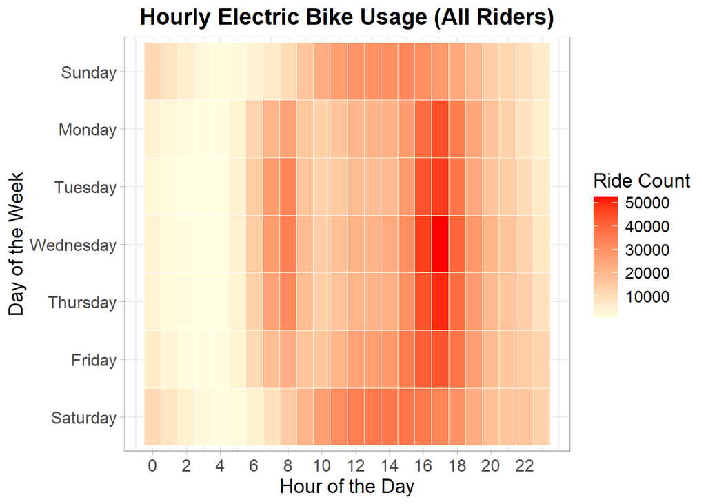

```r
# Electric bike usage heatmap
electric_data <- cleaned_data %>%
  filter(rideable_type == "electric_bike")
# All Riders
# Summarize electric bike rides by day_of_week and start_hour for all riders
electric_rides_all <- electric_data %>%
  group_by(day_of_week, start_hour) %>%
  summarise(ride_count = n(), .groups = "drop")

# Create the heatmap for all riders using electric bikes
plot_electric_all <- ggplot(electric_rides_all,
                            aes(x = start_hour, y = fct_rev(day_of_week), fill = ride_count)) +
  geom_tile(color = "white") +  # Adds white borders for clarity
  scale_fill_gradient(low = "lightyellow", high = "red") +  # Color gradient for ride count
  scale_x_continuous(breaks = seq(0, 23, by = 2)) +         # X-axis labels every 2 hours
  labs(
    title = "Hourly Electric Bike Usage (All Riders)",
    x = "Hour of the Day",
    y = "Day of the Week",
    fill = "Ride Count"
  ) +
  theme_light() +
  theme(
    plot.title = element_text(face = "bold", size = 16, hjust = 0.5),
    text = element_text(size = 14),
    axis.text.x = element_text(size = 12),
    axis.text.y = element_text(size = 12)
  )

# Display the plot
print(plot_electric_all)
```

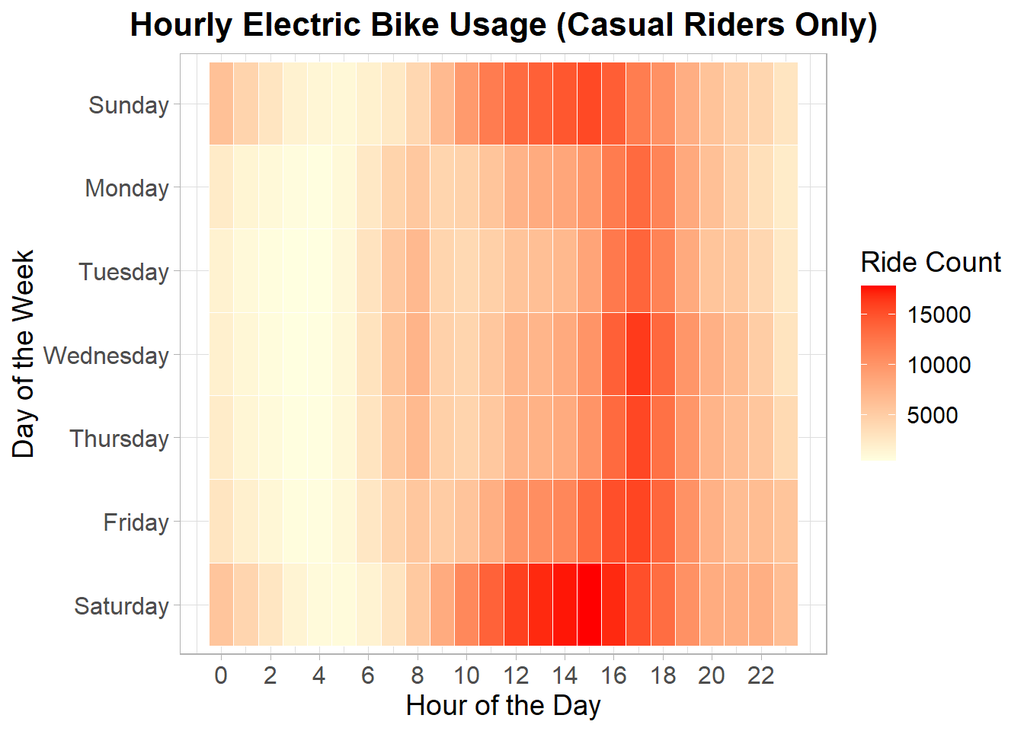

```r
# Casual Riders Only Electric Bike Heatmap
# Filter for casual riders only from the electric bike data
electric_data_casual <- electric_data %>%
  filter(member_casual == "casual")

# Summarize electric bike rides by day_of_week and start_hour for casual riders
electric_rides_casual <- electric_data_casual %>%
  group_by(day_of_week, start_hour) %>%
  summarise(ride_count = n(), .groups = "drop")

# Create the heatmap for casual riders using electric bikes
plot_electric_casual <- ggplot(electric_rides_casual,
                               aes(x = start_hour, y = fct_rev(day_of_week), fill = ride_count)) +
  geom_tile(color = "white") +
  scale_fill_gradient(low = "lightyellow", high = "red") +
  scale_x_continuous(breaks = seq(0, 23, by = 2)) +
  labs(
    title = "Hourly Electric Bike Usage (Casual Riders Only)",
    x = "Hour of the Day",
    y = "Day of the Week",
    fill = "Ride Count"
  ) +
  theme_light() +
  theme(
    plot.title = element_text(face = "bold", size = 16, hjust = 0.5),
    text = element_text(size = 14),
    axis.text.x = element_text(size = 12),
    axis.text.y = element_text(size = 12)
  )

# Display the casual riders' heatmap
print(plot_electric_casual)
```

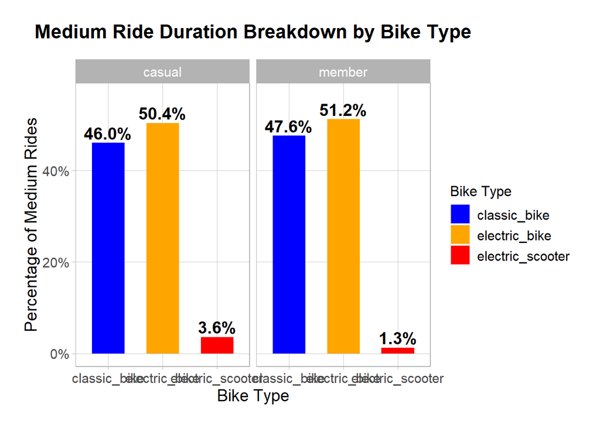

```r
# Filter data for medium rides only
medium_rides <- cleaned_data %>%
  filter(ride_category == "medium") %>%
  group_by(member_casual, rideable_type) %>%
  summarise(count = n(), .groups = "drop") %>%
  group_by(member_casual) %>%
  mutate(percent = (count / sum(count)) * 100)

# Create visualization for medium rides
plot_medium_rides <- ggplot(medium_rides, aes(x = rideable_type, y = percent, fill = rideable_type)) +
  geom_bar(stat = "identity", position = "dodge", width = 0.6) +
  geom_text(aes(label = sprintf("%.1f%%", percent)),
            position = position_dodge(width = 0.6), vjust = -0.3, size = 5, fontface = "bold") +
  scale_fill_manual(values = c("classic_bike" = "blue", "electric_bike" = "orange", "electric_scooter" = "red")) +
  labs(
    title = "Medium Ride Duration Breakdown by Bike Type",
    x = "Bike Type",
    y = "Percentage of Medium Rides",
    fill = "Bike Type"
  ) +
  facet_wrap(~member_casual) +  # Separate casual and member riders
  scale_y_continuous(labels = scales::percent_format(scale = 1)) +
  theme_light() +
  expand_limits(y = max(medium_rides$percent) * 1.1) +
  theme(
    plot.margin = margin(20, 20, 20, 20),
    text = element_text(size = 14),
    legend.title = element_text(size = 12),
    plot.title = element_text(face = "bold", size = 16, hjust = 0.5, margin = margin(b = 15)),
    panel.grid.major = element_line(color = "gray80"),
    panel.grid.minor = element_blank()
  )

print(plot_medium_rides)
```

### Analysis and Key Insights

- **eBike usage** when considering all rides is high during the weekday commute hours in the morning and afternoon and also on the weekends.
- The highest usage is Wednesday at 17:00 when looking at the all rides heatmap.
- Casual riders tend to heavily use eBikes on Saturdays and during afternoon commute hours, Wednesdays through Fridays.
- Casual and member riders prefer using eBikes for medium rides, which makes up a significant amount of overall rides.
- Marketing the cost benefits of member **eBike pricing** could encourage casual riders to subscribe.

## Seasonal Rider Usage Analysis

This section will evaluate the riding behavior of casual riders and members throughout the year.

```r
# Extract the month and create a summary dataset
monthly_rides <- cleaned_data %>%
  mutate(month = month(started_at, label = TRUE, abbr = FALSE)) %>%  # Extract full month name
  group_by(member_casual, month) %>%
  summarise(ride_count = n(), .groups = "drop") %>%
  mutate(month = factor(month, levels = month.name))  # Ensure correct order (Jan–Dec)

# Convert to wide format and add a total column
monthly_rides_table <- monthly_rides %>%
  pivot_wider(names_from = member_casual, values_from = ride_count, values_fill = 0) %>%
  mutate(
    Total = casual + member,  # Sum casual and member rides
    Percentage = (Total / sum(Total)) * 100  # Calculate percentage of total rides
  )

# Print the table with better formatting
kable(
  monthly_rides_table,
  caption = "Monthly Ride Counts by Rider Type (With Totals and Percentage)",
  digits = 1,
  format = "html"
) %>%
  kable_styling(full_width = FALSE, bootstrap_options = c("striped", "hover", "condensed")) %>%
  column_spec(1, bold = TRUE) %>%
  column_spec(5, width = "10em")
```

Monthly Ride Counts by Rider Type (With Totals and Percentage)

| month | casual | member | Total | Percentage |
| --- | --- | --- | --- | --- |
| January | 47715 | 230741 | 278456 | 4.7 |
| February | 46263 | 173810 | 220073 | 3.7 |
| March | 81004 | 215867 | 296871 | 5.0 |
| April | 129204 | 278945 | 408149 | 6.9 |
| May | 226389 | 373133 | 599522 | 10.1 |
| June | 297144 | 406788 | 703932 | 11.9 |
| July | 316406 | 425717 | 742123 | 12.5 |
| August | 314514 | 434424 | 748938 | 12.6 |
| September | 341516 | 470114 | 811630 | 13.7 |
| October | 214156 | 397303 | 611459 | 10.3 |
| November | 92074 | 240291 | 332365 | 5.6 |
| December | 37964 | 138580 | 176544 | 3.0 |

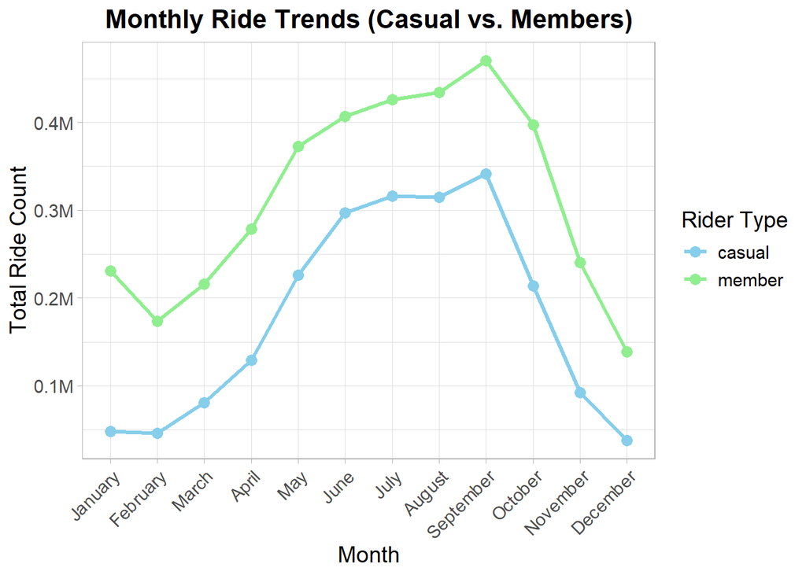

```r
# Create the line graph for monthly trends
plot_monthly_trends <- ggplot(monthly_rides, aes(x = month, y = ride_count, group = member_casual, color = member_casual)) +
  geom_line(linewidth = 1.2) +  # Line thickness
  geom_point(size = 3) +   # Add markers at each month
  scale_y_continuous(labels = scales::label_number(scale = 1e-6, suffix = "M")) +  # Format Y-axis as 1M, 2M, etc.
  scale_color_manual(values = c("casual" = "skyblue", "member" = "lightgreen")) +  # Set colors
  labs(
    title = "Monthly Ride Trends (Casual vs. Members)",
    x = "Month",
    y = "Total Ride Count",
    color = "Rider Type"
  ) +
  theme_light() +
  theme(
    plot.title = element_text(face = "bold", size = 16, hjust = 0.5),
    axis.text.x = element_text(angle = 45, hjust = 1),  # Rotate x-axis for readability
    text = element_text(size = 14)
  )

# Display the graph
print(plot_monthly_trends)
```

### Analysis and Key Insights

- The **majority of rides** occur from **May to October**. This suggests that bike usage is highly seasonal.
- Both casual and member ridership trends are similar, except in January and February when casual rider numbers drop significantly.
- Number of rides **increase** starting in March, **peaks** in September, and **decline sharply** in October to February.
- Casual rider count increase and decrease are **larger and sharper** compared to member ridership fluctuations.
- Casual ridership is highly seasonal compared to member ridership, suggesting an opportunity for seasonal membership options.
- While ridership falls drastically during the winter months, members maintain some level of **year round usage.**